**Instructor copy.** Executed notebook with all results shown, including the "after your attempt" cells. Projector/offline fallback; learners should use the notebook itself.

# f3 · Binary mixtures: composition, ideal mixing and chemical potentials

**Learning question:** when a second invented component B joins A in one phase, how do we count the atoms, what does mixing add to the Gibbs energy, and what do the chemical potentials μ_A and μ_B tell us?

Used in: Day 2 D1–D3, Lessons 3, 4 and 6, self-study step 02. Work each "your turn" on paper first, then type your value. Give numbers to at least four significant figures, or type the arithmetic itself and let Python evaluate it. Labels such as (W4), (D1), (Lesson 5) or Clinic D point to the printed one-day primers (Day 1 and Day 2 worksheets) and the detailed lessons of the classroom course in the repository. Working alone on the website, you only need the step numbers.

**The plan.** f1 and f2 had one kind of atom, so the only question was *which phase*. With two kinds of atoms, A and B, a phase can also have any *composition*, and the Gibbs energy becomes a curve against composition instead of a single number. The notebook builds that curve in three steps:

1. **Counting** (section 1): how to describe composition, and how amounts are kept when a sample is divided into regions.
2. **Ideal mixing** (section 2): the Gibbs energy of one phase as a function of its composition.
3. **Chemical potentials** (section 3): what the slope of that curve means, and how the tangent to the curve gives μ_A and μ_B.

These three ideas are what f4 needs to compare two phases.

```python
# Setup: run this cell first. Locally it finds the course folder; in Colab it
# downloads the tested course release and the locked package versions.
# In Colab, the first run then restarts the session on purpose and Colab reports
# a crash: that is expected. Run this cell again, then the rest of the notebook.
RELEASE = "main"
import os, pathlib, subprocess, sys, time
ROOT = next((p for p in (pathlib.Path.cwd(), *pathlib.Path.cwd().parents)
             if (p / "pyproject.toml").is_file() and (p / "course").is_dir()), None)
if ROOT is None and "google.colab" in sys.modules:
    ROOT = pathlib.Path("/content/CalphadIntro")
    if not ROOT.is_dir():
        clone = ["git", "clone", "-q", "--depth", "1", "--branch", RELEASE,
                 "https://github.com/ukerzel/CalphadIntro.git", str(ROOT)]
        git = dict(os.environ, GIT_TERMINAL_PROMPT="0")
        if subprocess.run(clone, env=git, capture_output=True).returncode:
            raise SystemExit(f"Could not download course release {RELEASE}: check the internet "
                             "connection and run this cell again.")
    if not (ROOT / ".colab-ready").exists():
        if subprocess.run([sys.executable, "-m", "pip", "install", "-q", "-r",
                           str(ROOT / "notebooks" / "requirements-colab.txt")]).returncode:
            raise SystemExit("Installing the course packages failed; run this cell again.")
        (ROOT / ".colab-ready").touch()
        # Colab has already loaded its own numpy; a fresh session is needed to use the installed versions.
        print("Installed the course's package versions. Colab now restarts this session and"
              " reports a crash; that is expected. When it has reconnected, run this cell again"
              " (it will not install twice), then the rest of the notebook.", flush=True)
        time.sleep(3)
        os.kill(os.getpid(), 9)
if ROOT is None:
    raise SystemExit("Open this notebook from the course folder (poetry run jupyter lab) or in Colab.")
os.chdir(ROOT)
sys.path.insert(0, str(ROOT))
from notebooks.helpers import check, confirm, database, show_versions
show_versions(RELEASE)
```

```
Course release main · Python 3.12.14
  numpy       2.5.3
  scipy       1.18.1
  matplotlib  3.11.2
  xarray      2026.7.0
  pycalphad   0.11.2
```

```
True
```

## 1. Composition and conserved amounts (D1, Lesson 3)

Two invented atom species A and B. All amounts are moles of **atoms**. The B atom fraction is $x_B = n_B/(n_A + n_B)$ and $x_A = 1 - x_B$; both are dimensionless. A ratio such as $n_B/n_A$ is something else: its denominator is not the total.

A **phase amount fraction** f says how much of the sample is in a region; a **phase composition** x says how B-rich that region is; the **overall composition** z counts B in the whole sample. For two regions, $f_1 + f_2 = 1$ and $z = f_1 x_1 + f_2 x_2$ (B balance); the A balance is $f_1(1 - x_1) + f_2(1 - x_2) = 1 - z$. A balanced split only checks the amounts; it does not show that the two regions are in equilibrium.

**Why the balances look like this.** Take one mole of atoms in total. Region 1 holds f_1 mol of atoms, and a fraction x_1 of those are B, so it holds f_1 x_1 mol of B. Region 2 likewise holds f_2 x_2 mol of B. No atom is created or lost, so the two B amounts must add up to the z mol of B in the whole sample. The same reasoning with the A fractions 1 − x gives the A balance. Adding the two balances gives back f_1 + f_2 = 1, so the second one is a useful check rather than new information.

The cell below first computes x_B, x_A and the ratio n_B/n_A for 3 mol A and 1 mol B, then checks both balances for a worked split. In the printout, compare x_B with the ratio: they are different numbers for the same sample.

```python
n_A, n_B = 3.0, 1.0                 # mol of atoms
x_B = n_B / (n_A + n_B)             # B atom fraction
print(f"x_B = {x_B:.2f}, x_A = {1 - x_B:.2f}, ratio n_B/n_A = {n_B / n_A:.4f}")   # :.2f = 2 decimals

# D1 worked count: two regions, half the atoms in each
f1, f2 = 0.5, 0.5                   # phase amount fractions
x1, x2 = 0.10, 0.50                 # B fraction inside each region
z = f1 * x1 + f2 * x2               # overall B fraction
a_balance = f1 * (1 - x1) + f2 * (1 - x2)   # overall A fraction; must equal 1 − z
print(f"z = {z:.2f}, A balance = {a_balance:.2f}, sum = {z + a_balance:.2f}")   # sum must be 1
```

```
x_B = 0.25, x_A = 0.75, ratio n_B/n_A = 0.3333
z = 0.30, A balance = 0.70, sum = 1.00
```

### Your turn (D1, step 02)

1. For nA = 0.6 mol and nB = 0.4 mol, give the amount ratio nB/nA (as a fraction typed as a division, or to four significant figures).
2. For 2 mol of atoms at z = 0.20, find n_B and n_A.
3. With x1 = 0.10, x2 = 0.50 and z = 0.20, find f2 from the B balance, then check the A balance: f1(1 − x1) + f2(1 − x2).

"The ALPHA composition x = 0.20 means 20 % of the sample's area is ALPHA." What information is missing to talk about area?

For item 3, replace f1 by 1 − f2 in the B balance; that leaves one equation with one unknown.

```python
ratio_nB_nA = None   # dimensionless
n_B_2mol = None      # mol
n_A_2mol = None      # mol
f2_trial = None      # phase amount fraction of region 2
A_balance = None     # A fraction of the whole sample
check(ratio_nB_nA, "f3_ratio_nb_na")
check(n_B_2mol, "f3_nb_2mol")
check(n_A_2mol, "f3_na_2mol")
check(f2_trial, "f3_f2_trial")
check(A_balance, "f3_a_balance")
```

```
f3_ratio_nb_na: not attempted yet. Replace None with your value and run the cell again.
f3_nb_2mol: not attempted yet. Replace None with your value and run the cell again.
f3_na_2mol: not attempted yet. Replace None with your value and run the cell again.
f3_f2_trial: not attempted yet. Replace None with your value and run the cell again.
f3_a_balance: not attempted yet. Replace None with your value and run the cell again.
```

### Atom fraction is not mass fraction

Mass and amount are linked by the molar mass: m = nM (grams with g/mol). For this exercise only, take **invented** molar masses M_A = 20 g/mol and M_B = 80 g/mol. For 3 mol A + 1 mol B:

The B mass fraction is $w_B = m_B/(m_A + m_B)$. Because a B atom here is four times as heavy as an A atom, the same sample has a much larger mass fraction of B than atom fraction of B. Thermodynamic models in this course always use atom (mole) fractions; alloy specifications often use mass fractions (wt%), so the conversion matters in practice.

```python
M_A, M_B = 20.0, 80.0               # g/mol, invented
m_A, m_B = n_A * M_A, n_B * M_B     # g  (mol × g/mol)
w_B = m_B / (m_A + m_B)             # B mass fraction
print(f"m_A = {m_A:.0f} g, m_B = {m_B:.0f} g, w_B = {w_B:.6f}, but x_B = {x_B:.2f}")
```

```
m_A = 60 g, m_B = 80 g, w_B = 0.571429, but x_B = 0.25
```

Lesson 3's two-box inventory, same invented masses:

| Box | A (mol) | B (mol) |
| --- | --- | --- |
| α | 0.45 | 0.05 |
| β | 0.30 | 0.20 |

### Your turn

1. A sample has 40 g A and 40 g B, so w_B = 0.5. What is x_B?
2. What fraction of the total **mass** is in β? (Its amount fraction is 0.5, its B fraction 0.4; neither is the answer.) Give it as a fraction typed as a division, or to four significant figures.

The route is always the same: convert every amount to the quantity you are asked about (grams to moles with n = m/M, or moles to grams with m = nM), and only then divide.

```python
x_B_40g = None             # dimensionless
beta_mass_fraction = None  # dimensionless
check(x_B_40g, "f3_xb_40g")
check(beta_mass_fraction, "f3_beta_mass_fraction")
```

```
f3_xb_40g: not attempted yet. Replace None with your value and run the cell again.
f3_beta_mass_fraction: not attempted yet. Replace None with your value and run the cell again.
```

### Your turn: units and amount basis

Supplied value: one model gives g_b = −10502.902 J/mol atoms at x = 0.10. Another report gives −10.50 **kJ/mol** at the same x.

1. Convert, then give the size of the difference in J/mol (a positive number). Does the rounding to 0.01 kJ/mol explain it?
2. What is the total G, in J, of 2 mol of atoms at x = 0.10? (Multiply J/mol by moles, never by an atom count.)

Reminder: 1 kJ = 1000 J. A value rounded to 0.01 kJ/mol can be off by up to half of that step. "J/mol atoms" means "per mole of atoms"; a molar quantity times an amount in mol gives a total in J.

```python
kJ_report_gap = None   # J/mol
G_2mol_x010 = None     # J
check(kJ_report_gap, "f3_kj_gap")
check(G_2mol_x010, "f3_g_2mol_x010")
```

```
f3_kj_gap: not attempted yet. Replace None with your value and run the cell again.
f3_g_2mol_x010: not attempted yet. Replace None with your value and run the cell again.
```

## 2. Ideal mixing (D2, Lesson 4)

One invented phase, ALPHA, at T = 1000 K and p = 100000 Pa, per mole of atoms. The pure endmembers have $g_A = -9000$ and $g_B = 3000$ J/mol, so the **reference line** is $-9000 + 12000x$. Ideal mixing adds $RT\,q(x)$ with R = 8.3145 J/(mol K), RT = 8314.5 J/mol and natural logarithms:

$$q(x) = (1-x)\ln(1-x) + x\ln x,\qquad g_b(x) = -9000 + 12000x + 8314.5\,q(x).$$

The ideal enthalpy **of mixing** is zero, yet the mixing Gibbs energy is negative for 0 < x < 1. At a pure end use the limit $0\ln 0 = 0$: then q = 0. Never ask a computer for ln 0; `scipy.special.xlogy(x, x)` returns the limit 0 at x = 0.

**Where each term comes from.** Here x is the B atom fraction of the phase and g_b its molar Gibbs energy (J per mole of atoms).

- *Reference line.* If A and B atoms did not notice each other, a mole of the phase would just be (1 − x) mol of pure A plus x mol of pure B: $(1-x)g_A + x\,g_B = -9000 + (3000 - (-9000))\,x = -9000 + 12000x$. This is a straight line from g_A at x = 0 to g_B at x = 1.
- *Mixing term.* Mixing A and B atoms at random on the sites creates many more possible arrangements than keeping them apart. Counting those arrangements (Boltzmann's $S = k_B \ln W$) gives the ideal entropy of mixing $\Delta s_{mix} = -R\,q(x)$. In an *ideal* solution there is no energy change on mixing, so the mixing Gibbs energy is only the entropy part: $\Delta g_{mix} = -T\Delta s_{mix} = RT\,q(x)$.
- *Sign.* For 0 < x < 1 both logarithms are of numbers below 1, so they are negative; q(x) < 0, and mixing lowers g.
- *R* is the gas constant, 8.3145 J/(mol K), and RT = 8314.5 J/mol at 1000 K.

**The Python.** `from scipy.special import xlogy` imports one function from SciPy. `xlogy(a, b)` computes a·ln(b), but returns exactly 0 when a = 0, which is the correct limit for 0 ln 0. The four small functions build g_b piece by piece, so each piece can be printed and checked separately. The `with np.errstate(...)` block only silences NumPy's warning while the cell deliberately shows what the naive 0 · ln 0 gives.

```python
import numpy as np
from scipy.special import xlogy

RT = 8314.5   # J/mol at 1000 K

def q_mix(x):
    return xlogy(1 - x, 1 - x) + xlogy(x, x)   # dimensionless, 0 at x = 0 and 1

def g_reference(x):
    return -9000.0 + 12000.0 * x               # J/mol atoms

def g_mixing(x):
    return RT * q_mix(x)                       # J/mol atoms

def g_b(x):
    return g_reference(x) + g_mixing(x)        # J/mol atoms

# Demonstration: ln(0) is −infinity, and 0 × (−infinity) is undefined (nan, "not a number").
with np.errstate(divide="ignore", invalid="ignore"):   # hide the warning for this one deliberate case
    print("naive 0 * ln(0) =", np.float64(0.0) * np.log(np.float64(0.0)), " ← not a number")
print("xlogy(0, 0)     =", xlogy(0.0, 0.0))

x_demo = 0.10   # D2 worked example
print(f"x = {x_demo}: q = {q_mix(x_demo):.8f}, reference = {g_reference(x_demo):.3f}, "
      f"mixing = {g_mixing(x_demo):.3f}, g_b = {g_b(x_demo):.3f} J/mol atoms")
```

```
naive 0 * ln(0) = nan  ← not a number
xlogy(0, 0)     = 0.0
x = 0.1: q = -0.32508297, reference = -7800.000, mixing = -2702.902, g_b = -10502.902 J/mol atoms
```

**What to look at.** At x = 0.10 the mixing term is negative and pulls g_b below the reference line. Check by hand that reference + mixing = g_b in the printout.

### Your turn (D2, step 02)

At x = 0.20, use q(0.20) = −0.50040242 to find the reference term, the mixing term and g_b, in J/mol atoms. Why is g_b not just 0.8 g_A + 0.2 g_B? Then: what is g_b at the pure-B end, x = 1?

```python
reference_020 = None   # J/mol atoms
mixing_020 = None      # J/mol atoms
g_b_020 = None         # J/mol atoms
g_b_pure_B = None      # J/mol atoms
check(reference_020, "f3_ref_020")
check(mixing_020, "f3_mix_020")
check(g_b_020, "f3_gb_020")
check(g_b_pure_B, "f3_gb_pure_b")
```

```
f3_ref_020: not attempted yet. Replace None with your value and run the cell again.
f3_mix_020: not attempted yet. Replace None with your value and run the cell again.
f3_gb_020: not attempted yet. Replace None with your value and run the cell again.
f3_gb_pure_b: not attempted yet. Replace None with your value and run the cell again.
```

### Lesson 4's table in code

This is the Lesson 4 cell with one change: its x = 0.2 and x = 0.8 rows contain your answers above, so they are left out here and printed after your attempt. Each row is x, g_ref, Δg_mix, total g (J/mol), total h (J/mol), total s (J/(mol K)). The rows are **different samples**, not regions of one sample.

**What the cell adds.** It splits g into enthalpy and entropy, g = h − Ts. The pure endmembers here have h_A = 1000 J/mol, h_B = 13000 J/mol and the same entropy s = 10 J/(mol K), so the reference enthalpy is the straight line h = 1000 + 12000x and g_ref = h − 10T. Ideal mixing adds nothing to h, but adds Δs_mix = −Rq to the entropy, so the total entropy is 10 + Δs_mix and the mixing Gibbs energy is −TΔs_mix.

**The Python.** `zip(x, gref, gmix, ...)` walks through the six arrays together and gives one row (a tuple of six numbers) at a time. In `' '.join(f'{v:.6f}' for v in row)` each number is formatted with six decimals and the pieces are joined with spaces into one line. `[central]` picks one element of an array by its position (Python counts from 0, so position 1 is the second row, x = 0.5).

```python
from scipy.special import xlogy

T = 1000.0                   # K
R = 8.3145                   # J/(mol K)
x = np.array([0.0, 0.5, 1.0])   # B atom fraction of three separate samples
h = 1000.0 + 12000.0*x       # J/mol, enthalpy (no enthalpy of mixing in an ideal solution)
gref = h - 10.0*T            # J/mol, reference Gibbs energy; both endmembers have s = 10 J/(mol K)
q = xlogy(x, x) + xlogy(1-x, 1-x)   # dimensionless, ≤ 0
smix = -R*q                  # J/(mol K), ideal entropy of mixing, ≥ 0
gmix = -T*smix               # J/mol, mixing Gibbs energy, ≤ 0
for row in zip(x, gref, gmix, gref+gmix, h, 10+smix):   # columns: x, g_ref, Δg_mix, g, h, s
    print(' '.join(f'{v:.6f}' for v in row))

central, pure_A = 1, 0       # row positions: 1 is x = 0.5, 0 is x = 0
confirm((gref + gmix)[central], -8763.172233, "Total g at x = 0.5", tol=1e-6)
confirm(gmix[central], -5763.172233, "Mixing term at x = 0.5", tol=1e-6)
confirm((10 + smix)[central], 15.763172, "Total s at x = 0.5", tol=1e-6)
confirm((gref + gmix)[pure_A], -9000.0, "Pure-A row: total g", tol=1e-9)
confirm(gmix[pure_A], 0.0, "Pure-A row: no mixing term", tol=1e-12)
```

```
0.000000 -9000.000000 0.000000 -9000.000000 1000.000000 10.000000
0.500000 -3000.000000 -5763.172233 -8763.172233 7000.000000 15.763172
1.000000 3000.000000 0.000000 3000.000000 13000.000000 10.000000
✓ Total g at x = 0.5 reproduces the lesson value.
✓ Mixing term at x = 0.5 reproduces the lesson value.
✓ Total s at x = 0.5 reproduces the lesson value.
✓ Pure-A row: total g reproduces the lesson value.
✓ Pure-A row: no mixing term reproduces the lesson value.
```

**What to look at.** At both pure ends the mixing column is 0 and the entropy column is 10: a pure substance has nothing to mix. At x = 0.5 the mixing term is largest in size, because a 50:50 mixture has the most possible arrangements.

So far g_b tells us the Gibbs energy of a whole mole of the phase at a given composition. The next question is how g changes when atoms are added or swapped: that is what chemical potentials measure.

## 3. Chemical potentials and the tangent (D3, Lesson 6)

The chemical potential μ_B is the change of total G when a little B is **added** with n_A fixed (μ_A likewise with n_B fixed). On a filled set of sites, putting in one B means taking out one A, so an **exchange** changes G by μ_B − μ_A, the slope of the molar curve:

$$g_b' = \mu_B - \mu_A,\qquad \mu_A = g_b - x\,g_b',\qquad \mu_B = g_b + (1-x)\,g_b'.$$

For this ideal ALPHA, inside 0 < x < 1:

$$\mu_A = -9000 + 8314.5\ln(1-x),\qquad \mu_B = 3000 + 8314.5\ln x,\qquad g_b' = 12000 + 8314.5\ln\frac{x}{1-x}.$$

The **tangent** at x0 is $\ell(x) = g_b(x_0) + g_b'(x_0)(x - x_0)$. At x = 0 it equals μ_A, at x = 1 it equals μ_B: the two ends of one tangent hold both chemical potentials. These are ends of a straight line, not g_b(0) or g_b(1). Derivatives exist only inside the interval, so x = 0 and x = 1 are excluded.

**Step by step.** Write the total Gibbs energy of the sample as $G(n_A, n_B) = n\,g_b(x)$ with $n = n_A + n_B$ and $x = n_B/n$. In symbols, $\mu_B = \partial G/\partial n_B$ at fixed $n_A$: the extra G per extra mole of B.

1. Adding $dn_B$ of B changes both n and x: $dn = dn_B$ and $dx = (1-x)\,dn_B/n$.
2. So $dG = g_b\,dn + n\,g_b'\,dx = [g_b + (1-x)\,g_b']\,dn_B$, which gives the formula for μ_B. The same steps with A (where $dx = -x\,dn_A/n$) give $\mu_A = g_b - x\,g_b'$.
3. Subtracting the two: $\mu_B - \mu_A = g_b'$. Multiplying μ_A by (1 − x), μ_B by x and adding: $(1-x)\mu_A + x\mu_B = g_b$.

For the ideal ALPHA the derivative of q is $q'(x) = -\ln(1-x) - 1 + \ln x + 1 = \ln\frac{x}{1-x}$, which gives the slope above. Putting it into $\mu_A = g_b - x\,g_b'$, the 12000x terms cancel and the logarithms combine to RT ln(1 − x). Each μ is "pure-element g plus RT ln(own atom fraction)", and it falls steeply as that atom fraction goes to 0.

**Why the tangent ends are μ_A and μ_B.** Put x = 0 into ℓ(x): ℓ(0) = g_b − x_0 g_b' = μ_A. Put x = 1: ℓ(1) = g_b + (1 − x_0) g_b' = μ_B. This picture (draw the tangent and read its two ends) is how chemical potentials are read off a Gibbs curve.

```python
def mu_A(x):
    return -9000.0 + RT * np.log(1 - x)        # J/mol atoms, 0 < x < 1

def mu_B(x):
    return 3000.0 + RT * np.log(x)             # J/mol atoms

def slope(x):
    return 12000.0 + RT * np.log(x / (1 - x))  # g_b' = mu_B − mu_A, J/mol atoms

def tangent(x, x0):
    return g_b(x0) + slope(x0) * (x - x0)      # J/mol atoms

for x0 in (0.10, 0.50):   # two touching points
    # line 1: both potentials, their difference and the slope (these two must agree)
    print(f"x0 = {x0}: mu_A = {mu_A(x0):.3f}, mu_B = {mu_B(x0):.3f}, "
          f"mu_B − mu_A = {mu_B(x0) - mu_A(x0):.3f}, slope = {slope(x0):.3f} J/mol atoms")
    # line 2: tangent ends (must equal mu_A and mu_B) and the weighted average (must equal g_b)
    print(f"   tangent at x = 0: {tangent(0.0, x0):.3f}, at x = 1: {tangent(1.0, x0):.3f}; "
          f"(1 − x) mu_A + x mu_B = {(1 - x0) * mu_A(x0) + x0 * mu_B(x0):.3f} = g_b = {g_b(x0):.3f}")
```

```
x0 = 0.1: mu_A = -9876.020, mu_B = -16144.844, mu_B − mu_A = -6268.824, slope = -6268.824 J/mol atoms
   tangent at x = 0: -9876.020, at x = 1: -16144.844; (1 − x) mu_A + x mu_B = -10502.902 = g_b = -10502.902
x0 = 0.5: mu_A = -14763.172, mu_B = -2763.172, mu_B − mu_A = 12000.000, slope = 12000.000 J/mol atoms
   tangent at x = 0: -14763.172, at x = 1: -2763.172; (1 − x) mu_A + x mu_B = -8763.172 = g_b = -8763.172
```

**What to look at.** For each x0, three pairs of numbers must agree: μ_B − μ_A and the slope; the tangent at x = 0 and μ_A; the tangent at x = 1 and μ_B. The last check, (1 − x)μ_A + xμ_B = g_b, says the molar Gibbs energy is the composition-weighted average of the two chemical potentials.

### The D3 tangent as a picture

Draw it once: the curve g_b, the tangent at the D3 composition x = 0.10, and its two end heights. The numbers come from the course module that also made the printed D3 figure, and the cell checks them against the formulas above. The dashed line is the reference −9000 + 12000x: μ_B lies far below pure B's reference value because a few B atoms among many A gain a large mixing term.

```
✓ mu_A at x = 0.10 reproduces the lesson value.
✓ mu_B at x = 0.10 reproduces the lesson value.
```

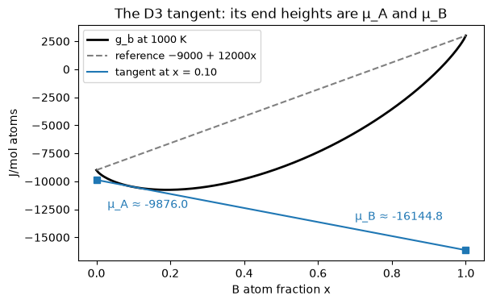

```python
import matplotlib.pyplot as plt
from course.print.paper_figures import d3_numbers   # the printed D3 figure's numbers

d3 = d3_numbers()                                    # tangent at x = 0.10: mu_A, mu_B, slope
confirm(mu_A(d3["x"]), d3["mu_A"], "mu_A at x = 0.10", tol=1e-6)
confirm(mu_B(d3["x"]), d3["mu_B"], "mu_B at x = 0.10", tol=1e-6)
xs = np.linspace(0.0, 1.0, 201)
fig, ax = plt.subplots(figsize=(6.5, 3.8))
ax.plot(xs, g_b(xs), "k-", lw=2, label="g_b at 1000 K")
ax.plot([0, 1], [d3["ref_A"], d3["ref_B"]], "--", color="grey", label="reference −9000 + 12000x")
ax.plot([0, 1], [d3["mu_A"], d3["mu_B"]], "-", color="tab:blue", label="tangent at x = 0.10")
ax.plot([0, 1], [d3["mu_A"], d3["mu_B"]], "s", color="tab:blue")
ax.annotate(f"μ_A ≈ {d3['mu_A']:.1f}", (0, d3["mu_A"]), (0.03, d3["mu_A"] - 2500), color="tab:blue")
ax.annotate(f"μ_B ≈ {d3['mu_B']:.1f}", (1, d3["mu_B"]), (0.7, d3["mu_B"] + 2700), color="tab:blue")
ax.set(xlabel="B atom fraction x", ylabel="J/mol atoms", title="The D3 tangent: its end heights are μ_A and μ_B")
ax.legend(fontsize=9, loc="upper left"); plt.show()
```

The advanced steps show these two heights coming out of an optimisation: the line a solver returns along with its answer.

### Addition is not exchange: Lesson 6's finite differences

Lesson 6's cell, written here with the g_b defined above, builds the total G(n_A, n_B) = n g_b(x) and changes the amounts directly at n_A = n_B = 0.5 mol. "Addition" adds B with A fixed (an estimate of μ_B); "exchange" swaps A for B at fixed total (an estimate of g_b'). Columns: step h (mol), addition (J/mol), exchange (J/mol). Predict both signs first.

**The numerical method.** A derivative can be estimated without any algebra by a *central difference*: change the input by +h and by −h, and divide the change of the output by the total step 2h:

$$\frac{dG}{dn} \approx \frac{G(n + h) - G(n - h)}{2h}.$$

The smaller h, the closer the estimate, until rounding errors of the computer start to matter at very small h. For the exchange, n_B goes up by h while n_A goes down by h, so the total n stays at 1 mol. In this cell `h` is the step in mol; it reuses the name of the enthalpy array above, which is not needed any more. `1e-3` is Python's way of writing 1 × 10⁻³, and the format `{h:.0e}` prints a number in that style.

```python
def total_G(nA, nB):
    n = nA + nB                     # mol of atoms
    return n * g_b(nB / n)          # J

for h in (1e-3, 1e-4, 1e-5, 1e-6):   # step size in mol
    addition = (total_G(.5, .5+h)-total_G(.5, .5-h))/(2*h)            # n_A fixed: estimate of mu_B, J/mol
    exchange = (total_G(.5-h, .5+h)-total_G(.5+h, .5-h))/(2*h)        # n_A + n_B fixed: estimate of g_b', J/mol
    print(f'{h:.0e} {addition:.6f} {exchange:.6f}')
```

```
1e-03 -2763.176390 12000.000000
1e-04 -2763.172274 12000.000000
1e-05 -2763.172233 12000.000000
1e-06 -2763.172233 12000.000001
```

**What to look at.** Read down each column: the estimates settle to fixed values as h shrinks. Compare the settled values with μ_B and the slope at x0 = 0.5 printed two cells above. Addition and exchange give clearly different numbers, because they are different questions. The next cell confirms both settled values.

```python
for step in (1e-5, 1e-6):   # the two smallest steps, in mol
    addition = (total_G(.5, .5 + step) - total_G(.5, .5 - step)) / (2 * step)
    exchange = (total_G(.5 - step, .5 + step) - total_G(.5 + step, .5 - step)) / (2 * step)
    confirm(addition, -2763.172233, f"Addition estimate of mu_B (h = {step:.0e} mol)", tol=1e-3)
    confirm(exchange, 12000.0, f"Exchange estimate of the slope (h = {step:.0e} mol)", tol=1e-3)
```

```
✓ Addition estimate of mu_B (h = 1e-05 mol) reproduces the lesson value.
✓ Exchange estimate of the slope (h = 1e-05 mol) reproduces the lesson value.
✓ Addition estimate of mu_B (h = 1e-06 mol) reproduces the lesson value.
✓ Exchange estimate of the slope (h = 1e-06 mol) reproduces the lesson value.
```

### Your turn (D3, step 02)

1. At x = 0.20, use ln(0.20/0.80) = −1.38629436 to find the exchange slope g_b'. Is it positive or negative? Then compute μ_A and μ_B at x = 0.20.
2. Take the tangent at x0 = 0.5. What is its value at x = 0.8?
3. Find the slope at x = 0.19. Between which two compositions on a 0.01 grid does the slope change sign? Solve g_b' = 0 for x exactly.
4. The slope changes sign somewhere between the pure ends. Does that mean two phases form? Write one sentence before you open the next section.

You may use the functions defined above (`slope`, `mu_A`, `mu_B`, `tangent`) to check your hand calculation, for example in a new line of the cell below. For item 3, set the slope formula equal to 0 and solve for x step by step: first isolate the logarithm, then undo it with the exponential function.

```python
slope_020 = None          # J/mol atoms
mu_A_020 = None           # J/mol atoms
mu_B_020 = None           # J/mol atoms
tangent_05_at_08 = None   # J/mol atoms
slope_019 = None          # J/mol atoms
x_zero_slope = None       # dimensionless
check(slope_020, "f3_slope_020")
check(mu_A_020, "f3_mua_020")
check(mu_B_020, "f3_mub_020")
check(tangent_05_at_08, "f3_tangent_05_at_08")
check(slope_019, "f3_slope_019")
check(x_zero_slope, "f3_x_zero_slope")
```

```
f3_slope_020: not attempted yet. Replace None with your value and run the cell again.
f3_mua_020: not attempted yet. Replace None with your value and run the cell again.
f3_mub_020: not attempted yet. Replace None with your value and run the cell again.
f3_tangent_05_at_08: not attempted yet. Replace None with your value and run the cell again.
f3_slope_019: not attempted yet. Replace None with your value and run the cell again.
f3_x_zero_slope: not attempted yet. Replace None with your value and run the cell again.
```

## After your attempt: the course code and the plots

Run these two cells once you have your own answers. The first repeats the step 02 and lesson numbers with `course.foundations.binary_family` and answers the two-phase question; the second draws the curves.

**About the first cell.** The course module `binary_family` (imported as `bf`) contains the same model written independently of this notebook:

- `bf.ideal_properties(T, x)` returns a dictionary with `"GM_reference"`, `"GM_mix"` and `"GM"` (all J/mol atoms), and also `"HM"` and `"SM"`.
- `bf.ideal_derivatives(T, x)` returns `"slope"`, `"mu_A"` and `"mu_B"`.
- `bf.lever_fraction(z, x1, x2)` solves the B balance for the fraction of the second region (f4 uses it again).

The values come back as NumPy arrays, so `float(...)` turns a single value into an ordinary number for printing and comparing.

**Finding the sign change on a grid.** `np.arange(1, 100) / 100` gives 0.01, 0.02, …, 0.99 and `np.round(..., 2)` removes tiny rounding leftovers. `grid_slope > 0` is an array of True/False; `np.argmax` of it returns the position of the first True, which is the first composition with a positive slope. The one before it is the last negative one. The exact zero follows from 12000 + RT ln(x/(1 − x)) = 0: x/(1 − x) = e^(−12000/RT), so x = 1/(1 + e^(12000/RT)); `math.exp` is the exponential function for a single number.

```python
#@title After your attempt: run to check the numbers with the course code
import math
from course.foundations import binary_family as bf

print("Step 02, worked answer: at x = 0.20 the reference is −6600, the mixing term about −4160.596\n"
      "and g_b about −10760.596 J/mol atoms; the exchange slope is about +473.656 J/mol atoms.\n"
      "Two moles at z = 0.20 hold 0.40 mol B and 1.60 mol A. The slope changes sign between\n"
      "x = 0.19 (about −56) and 0.20 (about +474): that is the lowest point of this one curve.\n"
      "It is not two phases forming. Only ALPHA was allowed, and a closed sample's composition\n"
      "is fixed by its amounts of A and B, so it stays homogeneous at that composition.\n"
      "Comparing two phases needs a second curve and a common tangent: that is f4.\n")
T = 1000.0   # K
props = bf.ideal_properties(T, 0.20)    # dictionary: GM_reference, GM_mix, GM, ... (J/mol atoms)
deriv = bf.ideal_derivatives(T, 0.20)   # dictionary: slope, mu_A, mu_B (J/mol atoms)
print(f"x = 0.20: reference {float(props['GM_reference']):.3f}, mixing {float(props['GM_mix']):.3f}, "
      f"g_b {float(props['GM']):.3f}, slope {float(deriv['slope']):.3f}, "
      f"mu_A {float(deriv['mu_A']):.3f}, mu_B {float(deriv['mu_B']):.3f} J/mol atoms")
confirm(float(props["GM_reference"]), -6600.0, "Step 02: reference at x = 0.20", tol=1e-6)
confirm(float(props["GM_mix"]), -4160.596, "Step 02: mixing term at x = 0.20", tol=1e-3)
confirm(float(props["GM"]), -10760.596, "Step 02: g_b at x = 0.20", tol=1e-3)
confirm(float(deriv["slope"]), 473.656, "Step 02: exchange slope at x = 0.20", tol=1e-3)
confirm(2 * 0.20, 0.40, "Step 02: mol B in 2 mol at z = 0.20", tol=1e-12)
confirm(bf.lever_fraction(0.20, 0.10, 0.50), 0.25, "D1: f2 for the balanced trial", tol=1e-12)

grid = np.round(np.arange(1, 100) / 100, 2)               # 0.01, 0.02, ..., 0.99
grid_slope = bf.ideal_derivatives(T, grid)["slope"]       # slope at every grid point, J/mol atoms
first_positive = int(np.argmax(grid_slope > 0))           # position of the first positive slope
print(f"sign change between x = {grid[first_positive - 1]:.2f} ({grid_slope[first_positive - 1]:.1f}) "
      f"and x = {grid[first_positive]:.2f} ({grid_slope[first_positive]:.1f}) J/mol atoms")
confirm(grid[first_positive - 1], 0.19, "Step 02: last negative slope on the 0.01 grid", tol=1e-12)
confirm(float(grid_slope[first_positive - 1]), -56.0, "Step 02: slope at x = 0.19 (about −56)", tol=0.5)
confirm(1 / (1 + math.exp(12000 / RT)), 0.191040753, "Lesson 6: zero of the ALPHA slope", tol=1e-9)   # exact zero of g_b'

# The course module and the formulas of section 3 must give the same mu_A, mu_B and tangent ends.
for x0 in (0.10, 0.20, 0.50):
    d = bf.ideal_derivatives(T, x0)
    confirm(float(d["mu_A"]), mu_A(x0), f"mu_A formula at x = {x0}", tol=1e-6)
    confirm(float(d["mu_B"]), mu_B(x0), f"mu_B formula at x = {x0}", tol=1e-6)
    confirm(tangent(0.0, x0), float(d["mu_A"]), f"Tangent at x = 0 is mu_A (x0 = {x0})", tol=1e-6)
    confirm(tangent(1.0, x0), float(d["mu_B"]), f"Tangent at x = 1 is mu_B (x0 = {x0})", tol=1e-6)

# The worked values quoted in the Day 2 primer and in Lesson 6
d10 = bf.ideal_derivatives(T, 0.10)
confirm(float(bf.ideal_properties(T, 0.10)["GM"]), -10502.902, "D2: g_b at x = 0.10", tol=1e-3)
confirm(float(d10["mu_A"]), -9876.020, "D3: mu_A at x = 0.10", tol=1e-3)
confirm(float(d10["mu_B"]), -16144.844, "D3: mu_B at x = 0.10", tol=1e-3)
confirm(float(d10["slope"]), -6268.824, "D3: mu_B − mu_A at x = 0.10", tol=1e-3)
d50 = bf.ideal_derivatives(T, 0.50)
confirm(float(d50["mu_A"]), -14763.172233, "Lesson 6: mu_A at x = 0.5", tol=1e-6)
confirm(float(d50["mu_B"]), -2763.172233, "Lesson 6: mu_B at x = 0.5", tol=1e-6)
confirm(float(d50["slope"]), 12000.0, "Lesson 6: slope at x = 0.5", tol=1e-9)
confirm(tangent(0.8, 0.5), -5163.172233, "Lesson 6: tangent at x0 = 0.5, read at x = 0.8", tol=1e-6)

print("\nLesson 4's full cell, now with its x = 0.2 and x = 0.8 rows (x, g_ref, Δg_mix, g, h, s):")
full = bf.ideal_properties(T, np.array([0.0, 0.2, 0.5, 0.8, 1.0]))
for row in zip([0.0, 0.2, 0.5, 0.8, 1.0], full["GM_reference"], full["GM_mix"], full["GM"], full["HM"], full["SM"]):
    print(' '.join(f'{v:.6f}' for v in row))
confirm(float(full["GM"][2]), -8763.172233, "Lesson 4: central row with the course module", tol=1e-6)
confirm(float(full["GM"][1]), -10760.596, "Lesson 4: total g at x = 0.2", tol=1e-3)
```

```
Step 02, worked answer: at x = 0.20 the reference is −6600, the mixing term about −4160.596
and g_b about −10760.596 J/mol atoms; the exchange slope is about +473.656 J/mol atoms.
Two moles at z = 0.20 hold 0.40 mol B and 1.60 mol A. The slope changes sign between
x = 0.19 (about −56) and 0.20 (about +474): that is the lowest point of this one curve.
It is not two phases forming. Only ALPHA was allowed, and a closed sample's composition
is fixed by its amounts of A and B, so it stays homogeneous at that composition.
Comparing two phases needs a second curve and a common tangent: that is f4.

x = 0.20: reference -6600.000, mixing -4160.596, g_b -10760.596, slope 473.656, mu_A -10855.327, mu_B -10381.672 J/mol atoms
✓ Step 02: reference at x = 0.20 reproduces the lesson value.
✓ Step 02: mixing term at x = 0.20 reproduces the lesson value.
✓ Step 02: g_b at x = 0.20 reproduces the lesson value.
✓ Step 02: exchange slope at x = 0.20 reproduces the lesson value.
✓ Step 02: mol B in 2 mol at z = 0.20 reproduces the lesson value.
✓ D1: f2 for the balanced trial reproduces the lesson value.
sign change between x = 0.19 (-56.1) and x = 0.20 (473.7) J/mol atoms
✓ Step 02: last negative slope on the 0.01 grid reproduces the lesson value.
✓ Step 02: slope at x = 0.19 (about −56) reproduces the lesson value.
✓ Lesson 6: zero of the ALPHA slope reproduces the lesson value.
✓ mu_A formula at x = 0.1 reproduces the lesson value.
✓ mu_B formula at x = 0.1 reproduces the lesson value.
✓ Tangent at x = 0 is mu_A (x0 = 0.1) reproduces the lesson value.
✓ Tangent at x = 1 is mu_B (x0 = 0.1) reproduces the lesson value.
✓ mu_A formula at x = 0.2 reproduces the lesson value.
✓ mu_B formula at x = 0.2 reproduces the lesson value.
✓ Tangent at x = 0 is mu_A (x0 = 0.2) reproduces the lesson value.
✓ Tangent at x = 1 is mu_B (x0 = 0.2) reproduces the lesson value.
✓ mu_A formula at x = 0.5 reproduces the lesson value.
✓ mu_B formula at x = 0.5 reproduces the lesson value.
✓ Tangent at x = 0 is mu_A (x0 = 0.5) reproduces the lesson value.
✓ Tangent at x = 1 is mu_B (x0 = 0.5) reproduces the lesson value.
✓ D2: g_b at x = 0.10 reproduces the lesson value.
✓ D3: mu_A at x = 0.10 reproduces the lesson value.
✓ D3: mu_B at x = 0.10 reproduces the lesson value.
✓ D3: mu_B − mu_A at x = 0.10 reproduces the lesson value.
✓ Lesson 6: mu_A at x = 0.5 reproduces the lesson value.
✓ Lesson 6: mu_B at x = 0.5 reproduces the lesson value.
✓ Lesson 6: slope at x = 0.5 reproduces the lesson value.
✓ Lesson 6: tangent at x0 = 0.5, read at x = 0.8 reproduces the lesson value.

Lesson 4's full cell, now with its x = 0.2 and x = 0.8 rows (x, g_ref, Δg_mix, g, h, s):
0.000000 -9000.000000 0.000000 -9000.000000 1000.000000 10.000000
0.200000 -6600.000000 -4160.595951 -10760.595951 3400.000000 14.160596
0.500000 -3000.000000 -5763.172233 -8763.172233 7000.000000 15.763172
0.800000 600.000000 -4160.595951 -3560.595951 10600.000000 14.160596
1.000000 3000.000000 0.000000 3000.000000 13000.000000 10.000000
✓ Lesson 4: central row with the course module reproduces the lesson value.
✓ Lesson 4: total g at x = 0.2 reproduces the lesson value.
```

**About the plotting cell.** It draws three panels side by side (`plt.subplots(1, 3)` returns the figure and three sets of axes):

- *Left:* g_b split into the reference line and the mixing term. The total is their sum.
- *Middle:* g_b with the tangent at x0, the touching point, and the two tangent ends marked as μ_A (square at x = 0) and μ_B (triangle at x = 1). Change `x0` in the first line and run again to see the tangent ends move.
- *Right:* μ_A, μ_B and their difference, the slope, against composition. The grey horizontal line marks zero, so you can see where the slope changes sign.

Two composition grids are used: `x_all` includes the pure ends (the curve is defined there, thanks to `xlogy`), `x_in` stays strictly inside, because ln 0 in μ_A or μ_B would be −∞. Energies are divided by 1000 to plot kJ/mol. Other plotting details: `plt.rcParams.update({"font.size": 12})` sets a larger default font, `markevery=10` puts a marker on every tenth point only, `fig.tight_layout()` stops the panels from overlapping. In the final table, a format like `{'x':>5}` prints the text right-aligned in a column 5 characters wide.

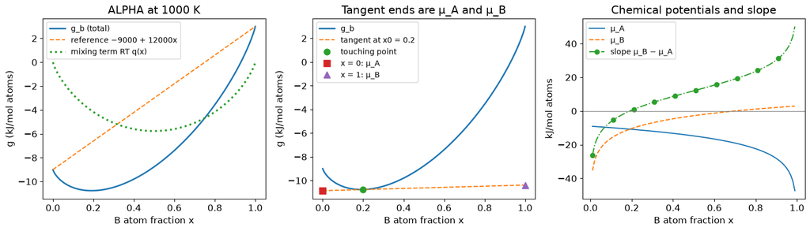

```
tangent at x0 = 0.2: mu_A = -10855.327, mu_B = -10381.672, slope = 473.656 J/mol atoms
    x  reference     mixing         g_b        mu_A        mu_B      slope   (J/mol atoms)
 0.01    -8880.0     -465.6     -9345.6     -9083.6    -35289.7   -26206.1
 0.10    -7800.0    -2702.9    -10502.9     -9876.0    -16144.8    -6268.8
 0.19    -6720.0    -4042.7    -10762.7    -10752.0    -10808.1      -56.1
 0.20    -6600.0    -4160.6    -10760.6    -10855.3    -10381.7      473.7
 0.50    -3000.0    -5763.2     -8763.2    -14763.2     -2763.2    12000.0
 0.80      600.0    -4160.6     -3560.6    -22381.7      1144.7    23526.3
 0.99     2880.0     -465.6      2414.4    -47289.7      2916.4    50206.1
```

```python
#@title After your attempt: plot the curve, a tangent and the chemical potentials
import matplotlib.pyplot as plt

x0 = 0.20   # composition of the tangent; change it (0 < x0 < 1) and run again
plt.rcParams.update({"font.size": 12})
x_all = np.linspace(0.0, 1.0, 201)       # pure ends included: 0 ln 0 = 0
x_in = np.linspace(0.01, 0.99, 99)       # derivatives: interior only
fig, (left, middle, right) = plt.subplots(1, 3, figsize=(15, 4.4))

# Left panel: the curve and its two parts (kJ/mol atoms)
left.plot(x_all, g_b(x_all) / 1000, "-", lw=2, label="g_b (total)")
left.plot(x_all, g_reference(x_all) / 1000, "--", label="reference −9000 + 12000x")
left.plot(x_all, g_mixing(x_all) / 1000, ":", lw=2.5, label="mixing term RT q(x)")
left.set(xlabel="B atom fraction x", ylabel="g (kJ/mol atoms)", title="ALPHA at 1000 K")
left.legend(fontsize=10)

# Middle panel: the tangent at x0 is a straight line, so two points (x = 0 and x = 1) draw it
middle.plot(x_all, g_b(x_all) / 1000, "-", lw=2, label="g_b")
middle.plot([0, 1], [tangent(0.0, x0) / 1000, tangent(1.0, x0) / 1000], "--", label=f"tangent at x0 = {x0}")
middle.plot([x0], [g_b(x0) / 1000], "o", ms=8, label="touching point")   # ms: marker size
middle.plot([0], [mu_A(x0) / 1000], "s", ms=9, label="x = 0: μ_A")
middle.plot([1], [mu_B(x0) / 1000], "^", ms=9, label="x = 1: μ_B")
middle.set(xlabel="B atom fraction x", ylabel="g (kJ/mol atoms)", title="Tangent ends are μ_A and μ_B")
middle.legend(fontsize=10)

# Right panel: chemical potentials and slope, interior compositions only
right.plot(x_in, mu_A(x_in) / 1000, "-", label="μ_A")
right.plot(x_in, mu_B(x_in) / 1000, "--", label="μ_B")
right.plot(x_in, slope(x_in) / 1000, "-.", marker="o", markevery=10, label="slope μ_B − μ_A")
right.axhline(0, color="grey", lw=0.8)   # horizontal line at zero
right.set(xlabel="B atom fraction x", ylabel="kJ/mol atoms", title="Chemical potentials and slope")
right.legend(fontsize=10)
fig.tight_layout()
plt.show()

print(f"tangent at x0 = {x0}: mu_A = {mu_A(x0):.3f}, mu_B = {mu_B(x0):.3f}, slope = {slope(x0):.3f} J/mol atoms")
print(f"{'x':>5} {'reference':>10} {'mixing':>10} {'g_b':>11} {'mu_A':>11} {'mu_B':>11} {'slope':>10}   (J/mol atoms)")
for xv in (0.01, 0.10, 0.19, 0.20, 0.50, 0.80, 0.99):
    print(f"{xv:5.2f} {g_reference(xv):10.1f} {g_mixing(xv):10.1f} {g_b(xv):11.1f} "
          f"{mu_A(xv):11.1f} {mu_B(xv):11.1f} {slope(xv):10.1f}")
```

**What to look at.** Left: the mixing term is zero at both ends and pulls the total below the reference line everywhere in between. Middle: the tangent touches the curve at x0 and its two ends sit at μ_A and μ_B, not at the curve's own end values. Right: μ_A drops steeply as x → 1 and μ_B as x → 0; the slope crosses zero where the curve has its lowest point.

**Limits.** A and B and the ALPHA phase are invented, with ideal mixing only; the numbers say nothing about a real alloy. Only one phase is allowed, so nothing here compares phases or finds an equilibrium between them: the lowest point of g_b is not the composition a closed sample takes, and a sign change of the slope is not a phase transition. Chemical potentials and slopes exist only for 0 < x < 1.

Worked answers, after your attempt: Day 2 answers (D1–D3), the worked answer of self-study step 02, and Lessons 3, 4 and 6.

Next: f4 · two phases and phase diagrams.